# Range diversity plots

### Range diversity plots

Based on Arita et al., 2011 Load libraries

```r
library(vegan)
library(permute)
library(lattice)
library(readr)
library(EcoSimR)
library(MASS)
```

## Step 1: create the presence-absence matrix (PAM) with s rows (species) and n columns (sites).

First, read the csv file with the list of number of individuals per OTU in each mountain. | Primero, se lee el documento csv con la lista de individuos de cada OTU por montaÃ±a

```r
OTUS <- read_csv("OTUs.csv")
OTUS<-OTUS[1:44,2:8] #Quitamos la columna de OTU porque es repetitiva
View(OTUS)
```

Convert the csv file to matrix and tranpose the matrix so that otus are in columns and sites in rows. Then, calculate a presence-absence matrix, where each cell will be first converted to T if there are one or more individuals in a site, and F if there are 0 individuals. Then, T are transformed to 1, and F to 0. | Se traspone la matriz para que las especies sean las columnas (variables) y los sitios los renglones. Después, se calcula una matriz de presencia-ausencia, en donde cada celda es transformada en T si hay al menos un individuo o más en el sitio, y F si hay 0 individuos. Después se transforman las T en 1 y las F en 0.

```r
OTUS.PA<-OTUS>0 #T and F instead of number of individuals
mode(OTUS.PA)<-"integer" # T=1 y F=0
head(OTUS)
```

```
## # A tibble: 6 x 7
##      An    Bl    To    Aj    Iz    Ma    Pe
##   <dbl> <dbl> <dbl> <dbl> <dbl> <dbl> <dbl>
## 1     0     0     5     0     0     0     0
## 2     0     0     0     0     0     4     0
## 3     0     0     0     0    10     3     1
## 4     0     0     0     0     2     0     0
## 5     0     0     0     0     0     0     2
## 6     0     0     0     1     0     0     0
```

```r
head(OTUS.PA)
```

```
##      An Bl To Aj Iz Ma Pe
## [1,]  0  0  1  0  0  0  0
## [2,]  0  0  0  0  0  1  0
## [3,]  0  0  0  0  1  1  1
## [4,]  0  0  0  0  1  0  0
## [5,]  0  0  0  0  0  0  1
## [6,]  0  0  0  1  0  0  0
```

```r
OTUS.PAM<- as.matrix(OTUS.PA)
OTUS.PAMt<-t(OTUS.PAM)
head(OTUS.PAMt)
```

```
##    [,1] [,2] [,3] [,4] [,5] [,6] [,7] [,8] [,9] [,10] [,11] [,12] [,13]
## An    0    0    0    0    0    0    0    1    0     0     0     0     0
## Bl    0    0    0    0    0    0    0    1    1     0     0     0     0
## To    1    0    0    0    0    0    0    1    1     0     0     0     0
## Aj    0    0    0    0    0    1    0    0    0     0     1     1     1
## Iz    0    0    1    1    0    0    0    0    0     1     0     0     1
## Ma    0    1    1    0    0    0    1    1    0     1     0     0     0
##    [,14] [,15] [,16] [,17] [,18] [,19] [,20] [,21] [,22] [,23] [,24] [,25]
## An     0     0     0     0     0     0     0     0     0     0     0     0
## Bl     0     1     0     1     0     1     0     0     0     0     0     0
## To     0     0     0     1     0     1     1     0     0     0     0     0
## Aj     1     0     0     1     0     1     0     1     1     1     1     1
## Iz     0     0     0     0     0     1     1     0     0     0     0     1
## Ma     0     0     0     1     1     0     0     0     0     0     0     0
##    [,26] [,27] [,28] [,29] [,30] [,31] [,32] [,33] [,34] [,35] [,36] [,37]
## An     1     0     0     0     0     0     0     1     0     0     0     0
## Bl     1     0     0     0     0     0     0     0     1     1     0     0
## To     0     0     0     0     0     0     0     0     0     0     0     1
## Aj     0     1     1     1     1     1     1     0     0     0     0     0
## Iz     0     1     0     0     0     0     0     0     0     0     0     0
## Ma     0     0     0     0     0     0     0     0     0     0     0     0
##    [,38] [,39] [,40] [,41] [,42] [,43] [,44]
## An     0     0     1     1     0     0     1
## Bl     0     1     0     0     0     0     0
## To     0     1     0     0     1     1     0
## Aj     0     0     0     0     0     0     0
## Iz     0     1     0     0     0     0     0
## Ma     0     0     0     0     0     0     0
```

## Step 2: Calculation of general parameters of range size and species richness

```r
Species<- nrow(OTUS.PAM)                          # S
Quadrats<- ncol(OTUS.PAM)                         # N
One_S<-as.matrix(seq(1, 1, length=Species))    # Vector of S 1s
One_N<-as.matrix(seq(1, 1, length=Quadrats))   # Vector of N 1s
SpeciesRichness<- as.matrix(colSums(OTUS.PAM))    # Vector of richness values
RangeSize<- as.matrix(rowSums(OTUS.PAM))          # Vector of range size values

Fill<- sum(RangeSize)                          # Fill of matrix
Beta<- Species*Quadrats/Fill                   # Whittaker's beta

RangeMean<- mean(RangeSize)                    # Overall mean range size
RangeMin<- min(RangeSize)
RangeMax<- max(RangeSize)
D_Volume<- OTUS.PAM%*%SpeciesRichness             # Vector of diversity field volume values
RangeRichness<- D_Volume/RangeSize             # Vector of range richness values
SpeciesCovariance<-(OTUS.PAM%*%OTUS.PAMt-RangeSize%*%t(RangeSize)/Quadrats)/Quadrats  #Variance-covariance matrix by species
RangeVariance<- RangeSize/Quadrats*(1-RangeSize/Quadrats)    # Vector of binary variances by species
VarianceOfRanges<-t(RangeSize)%*%RangeSize/Species-(t(One_S)%*%RangeSize/Species)^2  # Variance of range-size values
# This should be equal to var(RangeSize)*(Species-1)/Species

RichnessMean<- mean(SpeciesRichness)           # Overall mean species richness
RichnessMin<- min(SpeciesRichness)
RichnessMax<- max(SpeciesRichness)
R_Volume<- OTUS.PAMt%*%RangeSize                  # Vector of dispersion field volume values
SiteRange<- R_Volume/SpeciesRichness           # Vector of per-site range size values
SitesCovariance<- (OTUS.PAMt%*%OTUS.PAM-SpeciesRichness%*%t(SpeciesRichness)/Species)/Species    # Variance-covariance matrix by sites
RichnessVariance<- SpeciesRichness/Species*(1-SpeciesRichness/Species)   #Vector of binary variances by sites
VarianceOfRichness<-t(SpeciesRichness)%*%SpeciesRichness/Quadrats-(t(One_N)%*%SpeciesRichness/Quadrats)^2   #Variance of species-richness vlues
#This should be equal to var(SpeciesRichness)*(Quadrats-1)/Quadrats

CovarianceSpecies<- RangeSize*(RangeRichness-RichnessMean)/Quadrats/Species   #Vector of average covariance by species
CovarianceSites<- SpeciesRichness*(SiteRange-RangeMean)/Species/Quadrats      #Vector of average covariance by sites

V_species<- VarianceOfRichness/sum(RangeVariance)                              # Schluter's V by species
V_sites<- VarianceOfRanges/sum(RichnessVariance)                               # Schluter's V by sites
U_species<- sum(abs(RangeSize-RangeMean)/Quadrats)/Species
U_sites<- sum(abs(SpeciesRichness-RichnessMean)/Species)/Quadrats
```

## Step 3: Draw the RD plot by species

Define function species.plot Plot array based on Verzani, J. 2002, Using R for introductory statistics R help in http://www.stat.ucl.ac.be/ISdidactique/Rhelp/

```r
species.plot<- function() {
def.par <-par(no.readonly = TRUE)
xhist<- hist(RangeRichness/Species, breaks = seq(0, 1, .05), plot = FALSE)
yhist<- hist(RangeSize/Quadrats, breaks = seq(0, 1, .05), plot = FALSE)
topx<-max(xhist$counts)
topy<-max(yhist$counts)
nf<- layout(matrix(c(2, 0, 1, 3), 2, 2, T), c(6, 1), c(1, 6), TRUE)
layout.show(nf)
#RD plot
par(mar= c(5, 5, 1, 1))
plot(RangeRichness/Species, RangeSize/Quadrats, xlim = c(0,1), ylim = c(0, 1), xlab = "Proportional range richness", ylab = "Proportional range size")
#Isocovariance lines
x<- seq(RichnessMean/Species, 1, length = 100)
  for(i in c(.01, .05, .1)) {
      lines(x, i/(x- RichnessMean/Species), lwd = 2, col = "pink")
  }
  y<- seq(0, RichnessMean/Species, length = 100)
  for(j in c(-.01, -.05, -.1)) {
     lines(y, j/(y-RichnessMean/Species), lwd = 2, col = "pink")
  }
x<- seq(RichnessMin/Species, RichnessMean/Species, length = 100)
lines(x, (RichnessMax-RichnessMean)/Species/(RichnessMax/Species-x), lwd = 2)
y<- seq(RichnessMean/Species, RichnessMax/Species, length = 100)
lines(y, (RichnessMean-RichnessMin)/Species/(y-RichnessMin/Species), lwd = 2)
segments(RichnessMean/Species, 0, RichnessMean/Species, 1, lty = 3, lwd = 1.5)

#Top histogram
par(mar=c(0, 5, 1, 1))
barplot(xhist$counts, axes= FALSE, ylim = c(0, topx), space =0)

#Side histogram
par(mar=c(5, 0, 1, 1))
barplot(yhist$counts, axes = FALSE, space = 0, horiz = TRUE)

par(def.par)
}
```

## Step 4: Draw the RD plot by sites

```r
sites.plot<- function() {
def.par <-par(no.readonly = TRUE)
xhist<- hist(SiteRange/Quadrats, breaks = seq(0, 1, .05), plot = FALSE)
yhist<- hist(SpeciesRichness/Species, breaks = seq(0, 1, .05), plot = FALSE)
topx<-max(xhist$counts)
topy<-max(yhist$counts)
nf<- layout(matrix(c(2, 0, 1, 3), 2, 2, T), c(6, 1), c(1, 6), TRUE)
layout.show(nf)

#RD plot
par(mar= c(5, 5, 1, 1))
plot(SiteRange/Quadrats, SpeciesRichness/Species, xlim = c(0,1), ylim = c(0, 1), xlab = "Proportional per-site range", ylab = "Proportional species richness")

#ISOCOVARIANCE LINES
x<- seq(RangeMean/Quadrats, 1, length = 100)
   for(i in c(.01, .05, .1)) {
      lines(x, i/(x - RangeMean/Quadrats), lwd = 2, col = "pink")
   }
   y<- seq(0, RangeMean/Quadrats, length = 100)
   for(j in c(-.01, -.05, -.1)) {
      lines(y, j/(y- RangeMean/Quadrats), lwd = 2, col = "pink")
   }

x<- seq(RangeMin/Quadrats, RangeMean/Quadrats, length = 100)
lines(x, (RangeMax-RangeMean)/Quadrats/(RangeMax/Quadrats-x), lwd = 2)
y<- seq(RangeMean/Quadrats, RangeMax/Quadrats, length = 100)
lines(y, (RangeMean-RangeMin)/Quadrats/(y-RangeMin/Quadrats), lwd = 2)
segments(RangeMean/Quadrats, 0, RangeMean/Quadrats, 1, lty = 3, lwd = 1.5)

#Top histogram
par(mar=c(0, 5, 1, 1))
barplot(xhist$counts, axes= FALSE, ylim = c(0, topx), space =0)

#Side histogram
par(mar=c(5, 0, 1, 1))
barplot(yhist$counts, axes = FALSE, space = 0, horiz = TRUE)

par(def.par)
}
```

Display the plot by species using species.plot() and by sites using sites.plot(). To show a parameter type the corresponing command. For example, to display the set of range size values, type RangeSize We still need to edit this code, why is the plot template displayed? should we change the color?

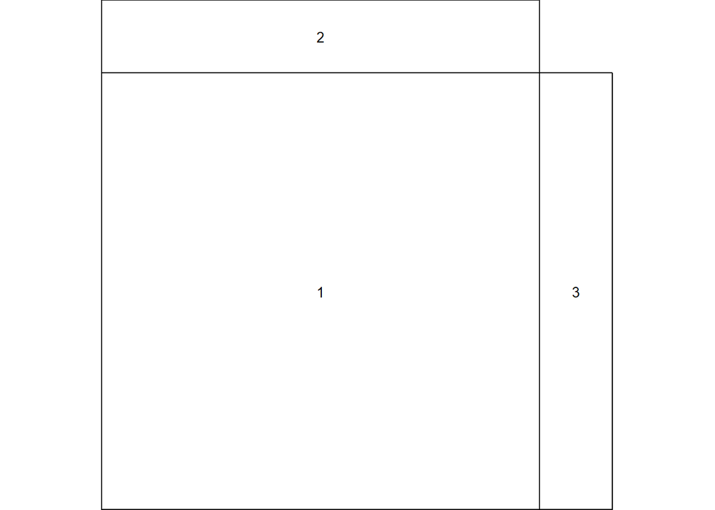

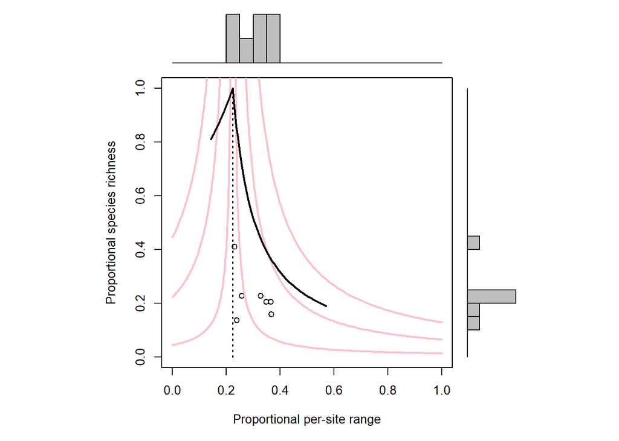

```r
sites.plot()
```

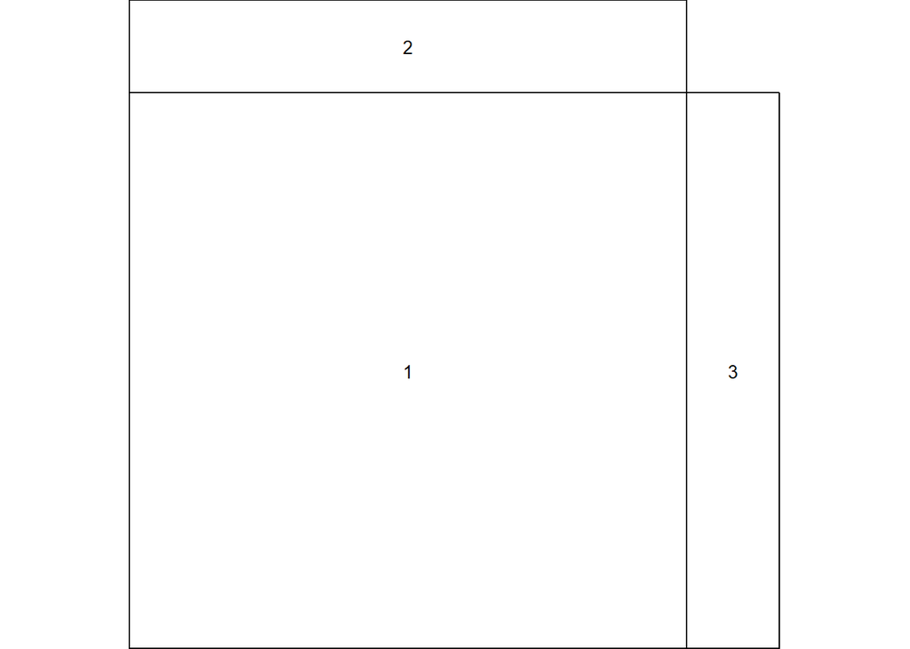

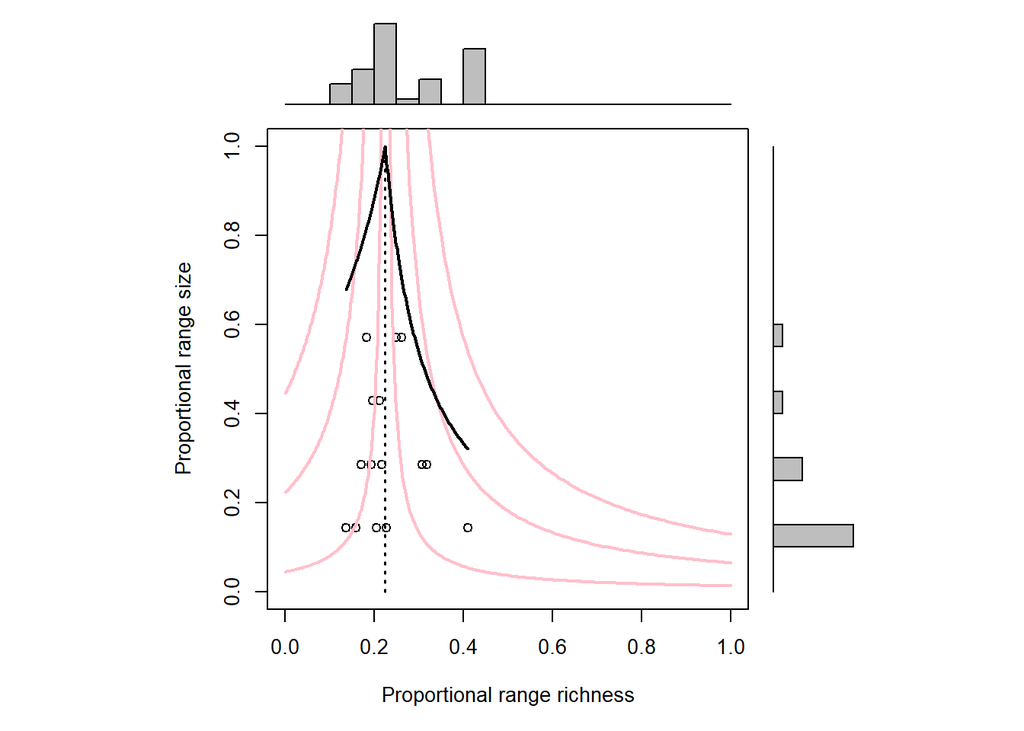

```r
species.plot()
```

## Null models

Now I’ll randomize the matrix to compare the empirical matrix to random ones, like in a null model. Using library EcoSimR. The function ra3

```r
nm <- ra3(OTUS.PAMt)
nm
```

```
##    [,1] [,2] [,3] [,4] [,5] [,6] [,7] [,8] [,9] [,10] [,11] [,12] [,13]
## An    0    0    0    0    0    0    1    0    0     0     1     0     0
## Bl    1    0    0    0    0    0    0    0    0     0     0     0     0
## To    0    1    0    0    0    1    0    0    0     1     0     0     0
## Aj    1    0    0    0    0    0    1    1    0     1     1     1     1
## Iz    0    0    0    0    0    1    0    0    0     1     0     0     0
## Ma    0    0    1    0    0    0    1    0    0     0     0     0     0
## Pe    0    0    0    1    0    1    0    0    0     0     0     1     0
##    [,14] [,15] [,16] [,17] [,18] [,19] [,20] [,21] [,22] [,23] [,24] [,25]
## An     0     1     0     0     0     0     0     0     0     0     1     0
## Bl     1     0     0     0     1     0     0     0     1     0     0     1
## To     1     0     0     0     0     0     1     0     1     0     0     0
## Aj     0     0     1     0     0     0     0     1     0     0     1     1
## Iz     0     0     1     0     1     0     0     1     0     1     0     0
## Ma     0     0     0     1     0     0     1     0     0     0     0     0
## Pe     0     0     0     0     0     1     0     1     0     0     0     0
##    [,26] [,27] [,28] [,29] [,30] [,31] [,32] [,33] [,34] [,35] [,36] [,37]
## An     0     0     0     0     0     0     0     0     0     0     0     0
## Bl     0     0     1     0     1     0     1     0     0     1     0     0
## To     0     0     1     0     0     1     0     0     0     0     0     0
## Aj     0     0     0     0     1     1     0     0     1     1     1     1
## Iz     0     0     0     0     1     0     0     1     0     0     0     0
## Ma     1     0     0     0     0     0     0     1     0     0     0     0
## Pe     1     1     0     0     0     0     0     0     0     1     0     1
##    [,38] [,39] [,40] [,41] [,42] [,43] [,44]
## An     1     1     0     0     0     0     0
## Bl     0     0     0     0     0     0     0
## To     0     0     0     1     1     0     0
## Aj     0     0     1     0     0     0     0
## Iz     1     0     0     0     0     0     0
## Ma     0     0     0     1     0     0     0
## Pe     0     0     0     1     0     0     0
```

```r
dim(nm)
```

```
## [1]  7 44
```

To get many matrices, I’ll use a loop: